# Habitat Metric PCA

Kate Culhane

February 12, 2019

### Correlated habitat variables

**Correlation plot of habitat variables:**

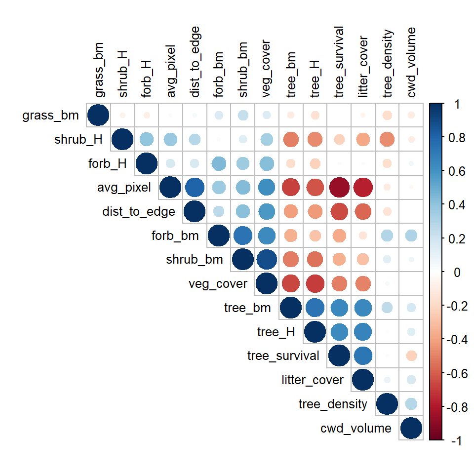

```
##       variable1     variable2 cor_strength
## 1 tree_survival     avg_pixel   -0.8662387
## 2  litter_cover     avg_pixel   -0.7741730
## 3  litter_cover tree_survival    0.7299939
## 4        tree_H       tree_bm    0.7335211
## 5       forb_bm      shrub_bm    0.7365690
## 6  dist_to_edge     avg_pixel    0.8031045
## 7     veg_cover      shrub_bm    0.8859965
```

**Highly correlated:**

- All fire variables:
  - tree_survival
  - avg_severity
  - dist_to_edge
  - litter cover
- veg cover & shrub biomass
- forb & shrub biomass
- tree diversity & biomass

### Collapse variables using PCA

#### Categories for collapsing:

**Fire**

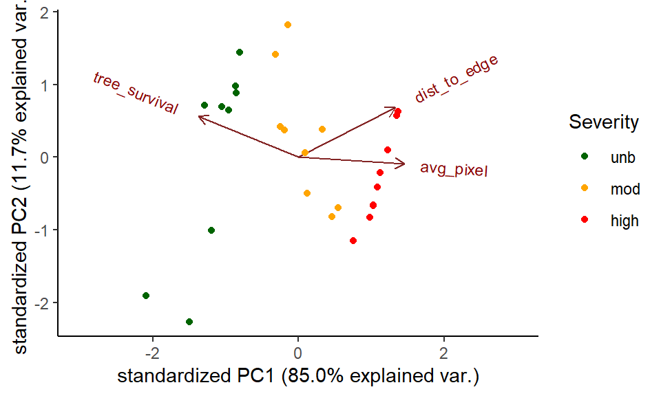

**Biomass**

- *tree_bm* - density of adult tree biomass (live or dead) (kg/m<sup>2</sup>)
- *shrub_bm* - density of live shrub biomass (kg/m<sup>2</sup>)
- *grass_bm* - density of live grass biomass (kg/m<sup>2</sup>)
- *forb_bm* - density of live forb biomass (kg/m<sup>2</sup>)

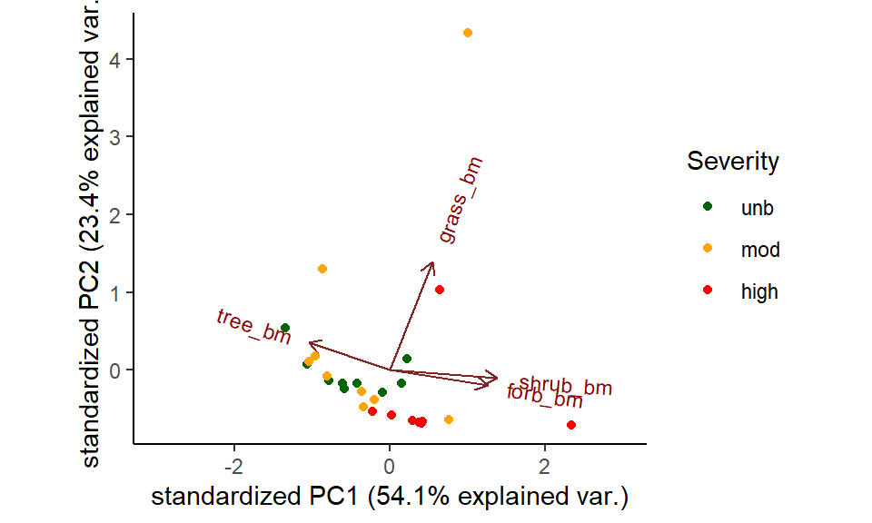

**Vegetation diversity**

- *tree_H* - Shannon diversity of adult trees
- *shrub_H* - Shannon diversity of adult trees
- *forb_H* - Shannon diversity of adult trees

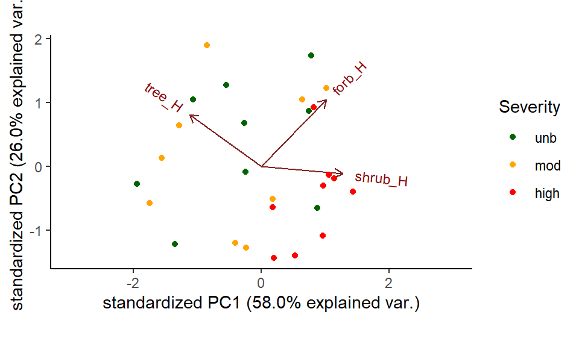

**Miscellaneous** (don’t collapse)

- *tree_density* - density of trees (live or dead) (indv/m<sup>2</sup>)
- *veg_cover* - total proportion of vegetation cover (all species/life-forms - can sum to >100) (both transects) (%)
- *litter_cover* - proportion of litter cover (%)
- *cwd_volume* - density of coarse woody debris volume (m<sup>3</sup>/m<sup>2</sup>)